# project3

Austin Melendez

2026-05-07

```r
#install.packages("keras")
#install.packages("magick")
#install.packages("ISLR2")
#install.packages("torch")
#install.packages("torchvision")
#install.packages("tidyverse")
#install.packages("knitr")
#install.packages("cluster")

library(keras)
library(magick)
library(ISLR2)
library(torch)
library(torchvision)
library(tidyverse)
library(knitr)
library(cluster)
```

# Project 3: Neural Networks & Clustering

## Introduction

This report has two parts. First, I use a pre-trained convolutional neural network to classify my own animal photographs and summarize the five most likely ImageNet classes for each image. Second, I use unsupervised learning methods to study repeat listening behavior in the LastFM portion of the UCI Repeat Consumption Matrices dataset.

## Part 1: Neural Networks

### Image Data

I selected ten animal photographs from my personal photos. I used images where the animal occupies a reasonable part of the frame, or where the image had been cropped so that the animal is visually central. The images are referenced below the model’s outputs for comparison.

### (From Your Revised Textbook Lab 10)

### Using Pretrained CNN Models

```r
setwd("C:/Users/Austin/Desktop/Everything/Coding/sacramento-state-university/STAT140B - Statistical Learning/Assignments/project3data/") # you will need to update this! #
img_dir <- "cnn"
image_names <- list.files(img_dir)
num_images <- length(image_names)
x <- torch_empty(num_images, 3, 224, 224)
for (i in 1:num_images) {
   img_path <- file.path(img_dir, image_names[i])
   img <- img_path %>%
     base_loader() %>%
     transform_to_tensor() %>%
     transform_resize(c(224, 224)) %>%

     # normalize with imagenet mean and stds.
     transform_normalize(
       mean = c(0.485, 0.456, 0.406),
       std = c(0.229, 0.224, 0.225)
     )
   x[i,,, ] <- img
}
```

Before sending the images through the model, I resized each image to 224 by 224 pixels and normalized the color channels using the ImageNet means and standard deviations. This preprocessing matters because the model was originally trained on images prepared in this same way.

I then load the trained ResNet-18 network. The model has 18 layers, with a fair bit of complexity.

```r
model <- torchvision::model_resnet18(pretrained = TRUE)
```

```
## Model weights for <resnet18> (~45 MB) will be downloaded and processed if not
## already available.
```

```r
model$eval() # put the model in evaluation mode
```

Finally, we classify our images, and return the top five class choices in terms of predicted probability for each.

```r
preds <- model(x)

mapping <- jsonlite::read_json("https://s3.amazonaws.com/deep-learning-models/image-models/imagenet_class_index.json") %>%
  sapply(function(x) x[[2]])

top5 <- torch_topk(preds, dim = 2, k = 5)

top5_prob <- top5[[1]] %>%
  nnf_softmax(dim = 2) %>%
  torch_unbind() %>%
  lapply(as.numeric)

top5_class <- top5[[2]] %>%
  torch_unbind() %>%
  lapply(function(x) mapping[as.integer(x)])

result <- purrr::map2(top5_prob, top5_class, function(pr, cl) {
  names(pr) <- cl
  pr
})

names(result) <- image_names
print(result)
```

```
## $australian_shepard.jpg
##        Border_collie             papillon               collie
##           0.53580266           0.14605108           0.13785441
##    Shetland_sheepdog Bernese_mountain_dog
##           0.09248216           0.08780971
##
## $bald_eagle.jpg
##    bald_eagle          kite     albatross American_coot   water_ouzel
##  0.9771782160  0.0205467716  0.0010158936  0.0006563884  0.0006026714
##
## $banana_slug.jpg
##          slug     stinkhorn        bolete hognose_snake  coral_fungus
##  0.9889692068  0.0079297153  0.0019668909  0.0006641375  0.0004699946
##
## $bird.jpg
##       robin       junco      coucal      bulbul house_finch
##  0.80485487  0.08133779  0.05319839  0.04515053  0.01545838
##
## $black_laborador.jpg
##         Great_Dane             kelpie    German_shepherd Labrador_retriever
##         0.47388259         0.25659084         0.12082455         0.07878025
##           Doberman
##         0.06992175
##
## $deer.jpg
##       ibex     impala   malinois    gazelle      llama
## 0.39813727 0.21394897 0.19084080 0.10835552 0.08871739
##
## $duck.jpg
## red-breasted_merganser            water_ouzel          American_coot
##             0.89111662             0.03795538             0.03069889
##                  drake                  goose
##             0.02878409             0.01144510
##
## $hawaiian_green_sea_turtle.jpg
## leatherback_turtle         loggerhead         mud_turtle           terrapin
##       0.9269205928       0.0670270920       0.0031975892       0.0027475837
##         grey_whale
##       0.0001070445
##
## $yellow_laborador.jpg
## Labrador_retriever             kuvasz       bull_mastiff     Great_Pyrenees
##         0.63027477         0.14839962         0.09145164         0.06987209
##   golden_retriever
##         0.06000183
##
## $yellow_laborador2.jpg
## Labrador_retriever   golden_retriever          dalmatian             beagle
##        0.929419518        0.037887976        0.015464014        0.008697305
##             Saluki
##        0.008531094
```

Overall, the pretrained model performed well on these images. Seven of the ten photos had a top prediction that matched the animal in the image closely: the bald eagle, banana slug, bird, duck, turtle, and both yellow Labrador photographs were classified with high confidence.

The Australian shepherd was classified as a Border collie, which is not exactly correct but is still a visually similar herding dog breed. The black Labrador and deer images were less successful: the black Labrador was predicted as a Great Dane, and the deer was predicted as an ibex. These errors are understandable because ImageNet contains many visually similar animal classes, and the model may respond strongly to pose, color, and background cues rather than to the exact animal identity.

The images I used are:

```r
library(jpeg)
library(png)
```

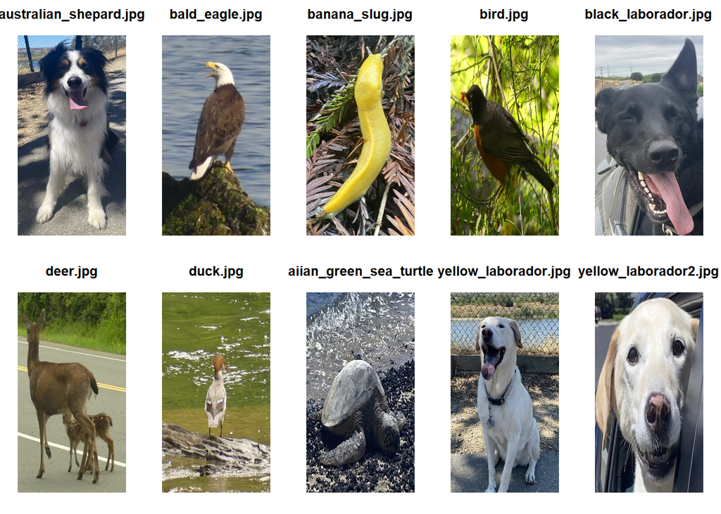

```r
img_dir <- "project3data/cnn"

image_names <- c(
  "australian_shepard.jpg",
  "bald_eagle.jpg",
  "banana_slug.jpg",
  "bird.jpg",
  "black_laborador.jpg",
  "deer.jpg",
  "duck.jpg",
  "hawaiian_green_sea_turtle.jpg",
  "yellow_laborador.jpg",
  "yellow_laborador2.jpg"
)

par(mfrow = c(2, 5), mar = c(1, 1, 2, 1))

for(i in 1:length(image_names)){

  img_path <- file.path(img_dir, image_names[i])
  img <- jpeg::readJPEG(img_path)

  plot(1:2,
       type = "n",
       axes = FALSE,
       xlab = "",
       ylab = "",
       main = image_names[i])

  rasterImage(img, 1, 1, 2, 2)
}
```

## Part 2: Unsupervised Learning

For the clustering portion of the project, I used the [Repeat Consumption Matrices dataset](https://archive.ics.uci.edu/dataset/441/repeat+consumption+matrices) from the UC Irvine Machine Learning Repository. The full dataset contains several user-item matrices from Reddit, Twitter, Gowalla, and LastFM. Each entry records how many times a user consumed an item. In the LastFM subset, each row represents a user, each column represents an artist, and each value is the number of times that user listened to that artist.

The goal of this analysis is to identify patterns in repeat consumer behavior using several unsupervised learning techniques discussed in ISLR2. Specifically, we apply:

- Principal Components Analysis (PCA)
- K-means clustering
- Hierarchical clustering

## 1. Dataset Description

The **primary goal** is to determine whether users naturally separate into distinct groups based on their listening behavior.

## 2. Loading Data

```r
data_file <- file.path("project3data", "lastfm", "train.csv")
if (!file.exists(data_file)) {
  stop("The LastFM file was not found at: ", data_file)
}
raw_data <- read.csv(data_file, header = FALSE)
colnames(raw_data) <- c("user", "artist", "count")
lastfm_overview <- tibble(
  rows = nrow(raw_data),
  users = n_distinct(raw_data$user),
  artists = n_distinct(raw_data$artist),
  total_listens = sum(raw_data$count),
  missing_values = sum(is.na(raw_data))
)

print(lastfm_overview)
```

```
## # A tibble: 1 × 5
##     rows users artists total_listens missing_values
##    <int> <int>   <int>         <int>          <int>
## 1 501519   937   15580      14206835              0
```

Before our analysis, we must first take the raw LastFM listening data and turns it into a smaller user-by-artist matrix that can be used for PCA and clustering.

```r
top_users <- raw_data |>
  group_by(user) |>
  summarise(total_listens = sum(count), .groups = "drop") |>
  slice_max(total_listens, n = 250, with_ties = FALSE)

top_artists <- raw_data |>
  group_by(artist) |>
  summarise(total_listens = sum(count), .groups = "drop") |>
  slice_max(total_listens, n = 50, with_ties = FALSE)

filtered <- raw_data |>
  filter(
    user %in% top_users$user,
    artist %in% top_artists$artist
  )

music_matrix <- xtabs(count ~ user + artist, data = filtered)

matrix_overview <- tibble(
  users = nrow(music_matrix),
  artists = ncol(music_matrix),
  nonzero_entries = sum(music_matrix > 0),
  sparsity = round(mean(music_matrix == 0), 3)
)

print(matrix_overview)
```

```
## # A tibble: 1 × 4
##   users artists nonzero_entries sparsity
##   <int>   <int>           <int>    <dbl>
## 1   249      50            7914    0.364
```

The filtered matrix is still sparse, meaning many users did not listen to many of the top artists. This is expected for music listening data: even active users tend to have concentrated preferences. Because a few very large play counts can dominate distances, I use `log1p(count)` before PCA and clustering.

```r
music_log <- log1p(as.matrix(music_matrix))

artist_sds <- apply(music_log, 2, sd)

music_log <- music_log[, artist_sds > 0, drop = FALSE]

music_scaled <- scale(music_log)
music_scaled <- as.matrix(music_scaled)
storage.mode(music_scaled) <- "double"
music_scaled <- unclass(music_scaled)

distinct_user_profiles <- nrow(unique(as.data.frame(music_scaled)))
```

This keeps the difference between 0 and 1 listen meaningful while reducing the influence of extreme listening counts.

## 3. Exploratory Data Analysis

I first examined the distribution of listening counts because clustering methods based on Euclidean distance are sensitive to scale and outliers. I also looked at user totals and artist totals to understand whether the filtered data are balanced or dominated by a small number of users or artists.

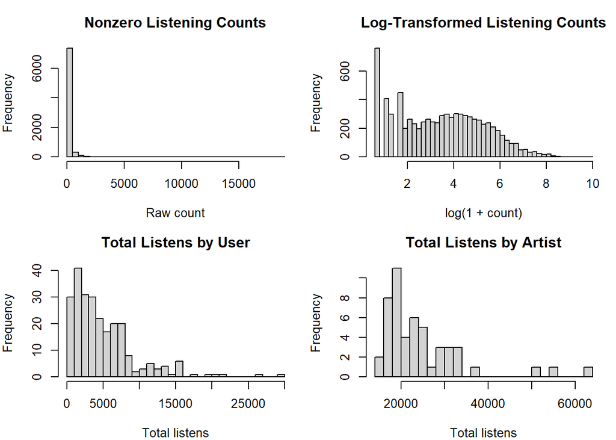

```r
nonzero_counts <- as.numeric(music_matrix[music_matrix > 0])
user_totals <- rowSums(music_matrix)
artist_totals <- colSums(music_matrix)

par(mfrow = c(2, 2), mar = c(4, 4, 3, 1))

hist(
  nonzero_counts,
  breaks = 40,
  main = "Nonzero Listening Counts",
  xlab = "Raw count"
)

hist(
  log1p(nonzero_counts),
  breaks = 40,
  main = "Log-Transformed Listening Counts",
  xlab = "log(1 + count)"
)

hist(
  user_totals,
  breaks = 25,
  main = "Total Listens by User",
  xlab = "Total listens"
)

hist(
  artist_totals,
  breaks = 25,
  main = "Total Listens by Artist",
  xlab = "Total listens"
)
```

The raw counts are strongly right-skewed, with many small positive counts and a smaller number of very large values. After the log transformation, the distribution is less extreme. This supports using the log-transformed matrix for PCA and clustering rather than clustering directly on raw listening counts.

## 4. Analysis

### Principal Components Analysis

I applied PCA to the scaled log-count matrix. Scaling is important because each artist is treated as a feature, and I wanted the PCA directions to reflect patterns across artists rather than simply giving more weight to artists with larger variance.

```r
pca_fit <- prcomp(music_scaled, center = FALSE, scale. = FALSE)

pve <- pca_fit$sdev^2 / sum(pca_fit$sdev^2)

cumulative_pve <- cumsum(pve)

pca_summary <- tibble(
  component = paste0("PC", 1:10),
  proportion_variance = round(pve[1:10], 3),
  cumulative_variance = round(cumulative_pve[1:10], 3)
)

print(pca_summary)
```

```
## # A tibble: 10 × 3
##    component proportion_variance cumulative_variance
##    <chr>                   <dbl>               <dbl>
##  1 PC1                     0.255               0.255
##  2 PC2                     0.088               0.343
##  3 PC3                     0.08                0.423
##  4 PC4                     0.053               0.476
##  5 PC5                     0.045               0.521
##  6 PC6                     0.035               0.556
##  7 PC7                     0.031               0.587
##  8 PC8                     0.024               0.611
##  9 PC9                     0.022               0.633
## 10 PC10                    0.021               0.654
```

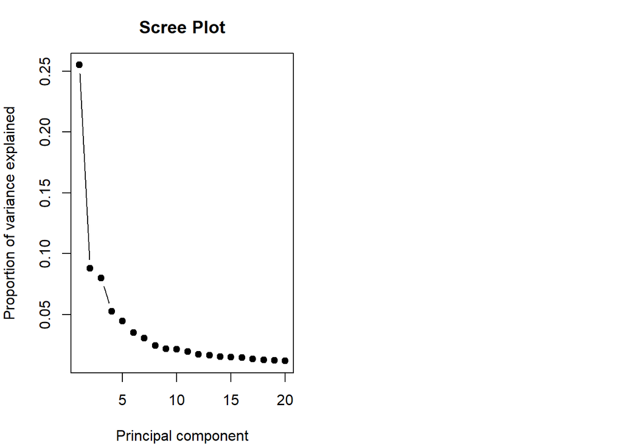

```r
par(mfrow = c(1, 2), mar = c(4, 4, 3, 1))
plot(
  pve[1:20],
  type = "b",
  pch = 19,
  main = "Scree Plot",
  xlab = "Principal component",
  ylab = "Proportion of variance explained"
)
```

The scree plot helps decide how many principal components contain meaningful structure. I do not expect the first component to explain all of the variation because music taste is complex and the data contain many artists. In this analysis, the plot begins to flatten more noticeably around the fourth principal component, so it would be reasonable to focus on the first four principal components as a lower-dimensional summary of the strongest listening patterns.

### Choosing the Number of Clusters

For k-means, I considered values of `k` from 2 through 8. I used two diagnostics: the elbow plot based on total within-cluster sum of squares and the average silhouette width. The elbow plot looks for a point where adding more clusters gives diminishing returns. The silhouette score measures how well separated the resulting clusters are.

```r
max_k <- min(8, distinct_user_profiles - 1)
k_grid <- 2:max_k

kmeans_wss <- map_dbl(k_grid, function(k) {
  kmeans(music_scaled, centers = k, nstart = 25)$tot.withinss
})

kmeans_sil <- map_dbl(k_grid, function(k) {
  km <- kmeans(music_scaled, centers = k, nstart = 25)
  mean(silhouette(km$cluster, dist(music_scaled))[, 3])
})

best_k <- k_grid[which.max(kmeans_sil)]

cluster_choice <- tibble(
  k = k_grid,
  total_within_ss = round(kmeans_wss, 1)
)

print(cluster_choice)
```

```
## # A tibble: 7 × 2
##       k total_within_ss
##   <int>           <dbl>
## 1     2          10164.
## 2     3           9578.
## 3     4           9084.
## 4     5           8700.
## 5     6           8416
## 6     7           8169.
## 7     8           7975
```

Let’s check our best $k$ value.

```r
print(best_k)
```

```
## [1] 2
```

We see that $k=2$ is our best value.

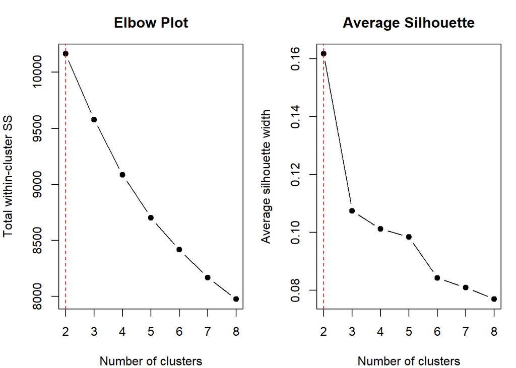

```r
par(mfrow = c(1, 2), mar = c(4, 4, 3, 1))

plot(
  k_grid,
  kmeans_wss,
  type = "b",
  pch = 19,
  main = "Elbow Plot",
  xlab = "Number of clusters",
  ylab = "Total within-cluster SS"
)
abline(v = best_k, lty = 2, col = "red")

plot(
  k_grid,
  kmeans_sil,
  type = "b",
  pch = 19,
  main = "Average Silhouette",
  xlab = "Number of clusters",
  ylab = "Average silhouette width"
)
abline(v = best_k, lty = 2, col = "red")
```

Based on these diagnostics, I use 2 clusters for both k-means and hierarchical clustering. Using the same number of clusters makes the two methods easier to compare.

### K-Means Clustering

K-means clustering partitions the users into groups by minimizing the within cluster squared distance. Because k-means can depend on the initial cluster centers, I used `nstart = 50` so that R tries multiple random initializations and keeps the best solution.

```r
km_fit <- kmeans(music_scaled, centers = best_k, nstart = 50)
```

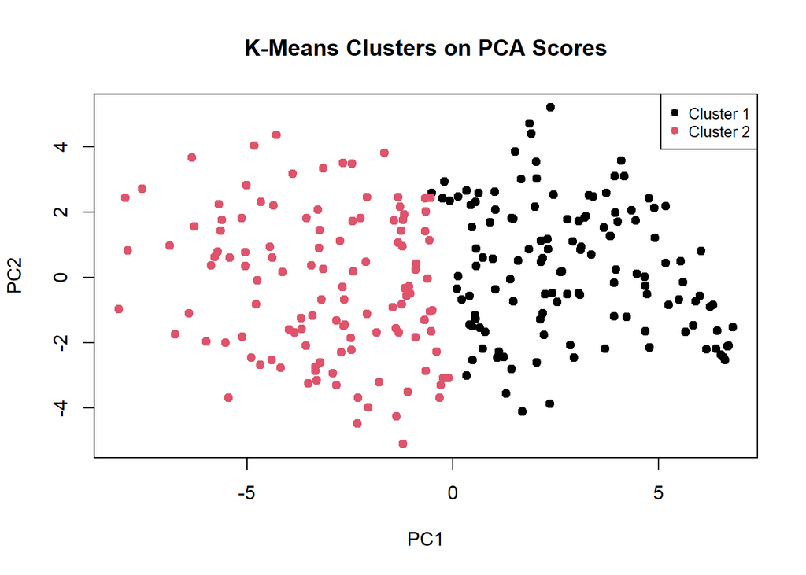

```r
plot(
  pca_fit$x[, 1],
  pca_fit$x[, 2],
  col = km_fit$cluster,
  pch = 19,
  main = "K-Means Clusters on PCA Scores",
  xlab = "PC1",
  ylab = "PC2"
)
legend(
  "topright",
  legend = paste("Cluster", sort(unique(km_fit$cluster))),
  col = sort(unique(km_fit$cluster)),
  pch = 19,
  cex = 0.8
)
```

To interpret the clusters, I compared each cluster’s average log listening count for each artist. The table below lists the artists with the highest cluster averages, which gives a short description of what each cluster listens to most.

```r
music_log_mat <- as.matrix(unclass(music_log))

music_log_df <- as.data.frame(music_log_mat, check.names = FALSE)

colnames(music_log_df) <- make.unique(colnames(music_log_df))

music_log_df$user_id <- rownames(music_log_mat)
music_log_df$cluster <- factor(km_fit$cluster)

cluster_profiles <- music_log_df |>
  pivot_longer(
    cols = -c(user_id, cluster),
    names_to = "artist",
    values_to = "log_count"
  ) |>
  group_by(cluster, artist) |>
  summarise(avg_log_count = mean(log_count), .groups = "drop") |>
  group_by(cluster) |>
  slice_max(avg_log_count, n = 5, with_ties = FALSE) |>
  arrange(cluster, desc(avg_log_count)) |>
  mutate(avg_log_count = round(avg_log_count, 2))

print(cluster_profiles)
```

```
## # A tibble: 10 × 3
## # Groups:   cluster [2]
##    cluster artist avg_log_count
##    <fct>   <chr>          <dbl>
##  1 1       8651            2.72
##  2 1       9123            2.43
##  3 1       10675           2.41
##  4 1       10194           2.39
##  5 1       12786           2.21
##  6 2       10548           5.11
##  7 2       12786           4.3
##  8 2       6153            4.02
##  9 2       12986           3.99
## 10 2       902             3.92
```

These cluster profiles are more interpretable than the cluster labels by themselves. If one cluster has high averages for a coherent set of artists, that suggests a group of users with similar listening preferences. If several clusters share the same top artists, then the clustering may be separating users more by listening intensity than by genre or taste.

### Hierarchical Clustering

I also applied hierarchical clustering using complete linkage and Euclidean distance on the same scaled log-count data. Complete linkage tends to form more compact clusters than single linkage, which is useful here because I want groups of users that are reasonably close to all other users in the same cluster.

```r
user_dist <- dist(music_scaled)

hc_complete <- hclust(user_dist, method = "complete")
hc_clusters <- cutree(hc_complete, k = best_k)

hc_sizes <- tibble(
  cluster = names(table(hc_clusters)),
  users = as.integer(table(hc_clusters))
)

print(hc_sizes)
```

```
## # A tibble: 2 × 2
##   cluster users
##   <chr>   <int>
## 1 1          78
## 2 2         171
```

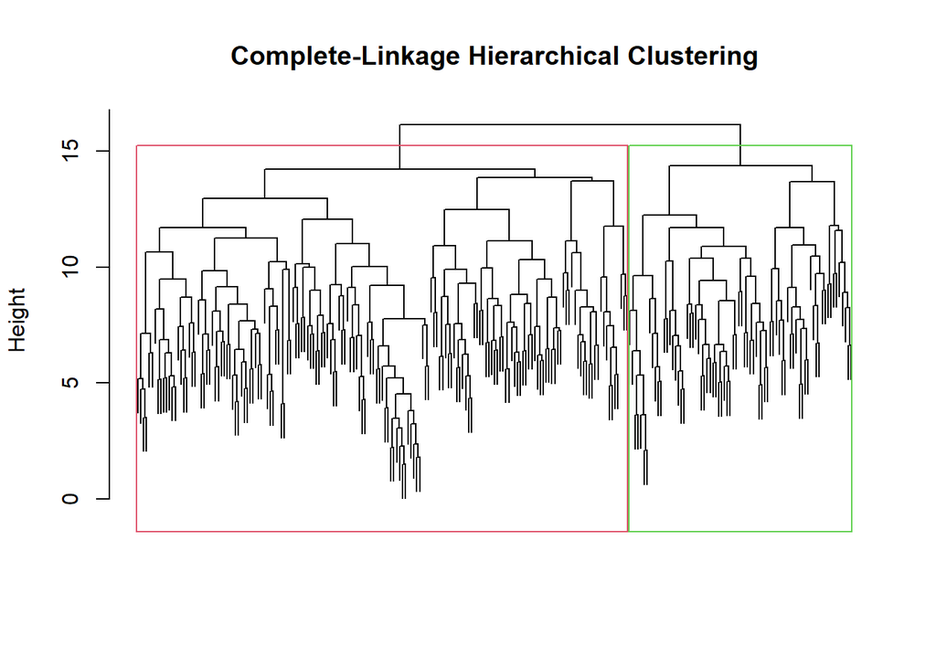

```r
plot(
  hc_complete,
  labels = FALSE,
  main = "Complete-Linkage Hierarchical Clustering",
  xlab = "",
  sub = ""
)

rect.hclust(hc_complete, k = best_k, border = 2:(best_k + 1))
```

The dendrogram shows how users merge into larger groups as the distance threshold increases. Cutting the tree at 2 clusters lets me compare hierarchical clustering with the k-means solution while still respecting the structure suggested by the dendrogram.

### Comparing the Clustering Methods

```r
cluster_comparison <- table(
  KMeans = km_fit$cluster,
  Hierarchical = hc_clusters
)

print(cluster_comparison)
```

```
##       Hierarchical
## KMeans   1   2
##      1   1 128
##      2  77  43
```

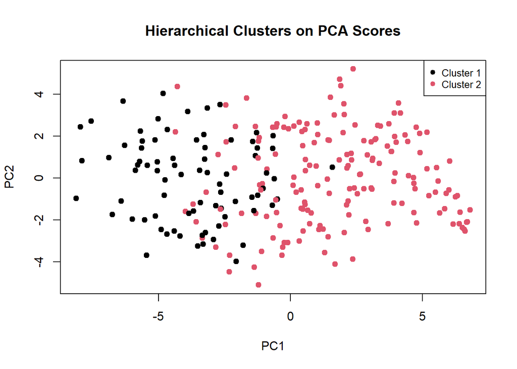

```r
plot(
  pca_fit$x[, 1],
  pca_fit$x[, 2],
  col = hc_clusters,
  pch = 19,
  main = "Hierarchical Clusters on PCA Scores",
  xlab = "PC1",
  ylab = "PC2"
)
legend(
  "topright",
  legend = paste("Cluster", sort(unique(hc_clusters))),
  col = sort(unique(hc_clusters)),
  pch = 19,
  cex = 0.8
)
```

K-means and hierarchical clustering answer similar questions in different ways. K-means directly optimizes compact clusters around centroids, while hierarchical clustering builds a tree of user similarity. Agreement between the two methods would suggest stable structure in the listening data. Disagreement would suggest that the data do not separate into sharply defined groups, or that different clustering algorithms are emphasizing different aspects of user behavior.

## 5. Conclusion

The CNN portion of the project shows how a pretrained ImageNet model can be used to classify personal animal photographs without training a new neural network. The model is most useful when its top predictions are interpreted as plausible visual categories rather than perfect labels.

For the unsupervised learning portion, the LastFM data required preprocessing because the original matrix is sparse, high-dimensional, and right-skewed. I filtered to active users and popular artists, used a log transformation to reduce the effect of extreme play counts, and scaled the artist features before applying PCA and clustering. PCA provided a lower-dimensional view of the strongest patterns in listening behavior, while k-means and hierarchical clustering grouped users according to similarity in their artist listening profiles.

Overall, the strongest conclusion is that repeat listening behavior contains some cluster structure, but the interpretation of those clusters depends on both the preprocessing choices and the clustering method. The most meaningful cluster descriptions come from examining the artists that define each group, not from the cluster numbers alone.